# Conducting t-tests in R

10/5/2018

## Setup for today

- Install the `tidyr` package
- Download `Example 1.csv` from Canvas
- Open a new notebook, save it, and load in these .csv files

```r
# For example:
example1 <- read.csv("Example 1.csv")
```

## Overview

- More fun with `ggplot2`
- Tidying up your data
- One sample t-test
- Two sample t-test
  - x, y interface
  - formula interface
- Formulas in R

## Plotting comparisons of group means

## More fun with `ggplot2`

- Two-sample t-tests ask if two group means came from different distributions
- So, plots to go along with t-tests should show means and some measure of spread or distribution
- What plots have we learned so far that do this?

## More fun with `ggplot2`

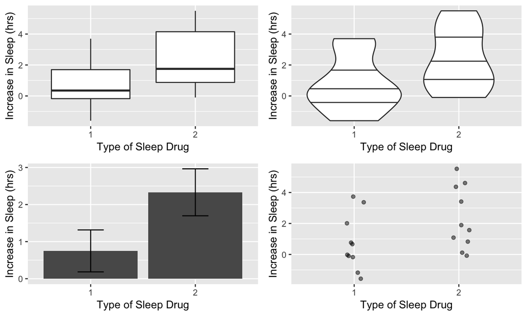

## Making bar plots better

- Bar plots on their own do a poor job of displaying data, even with error bars
- Adding the actual data points on top can improve them

## LIVE CODING

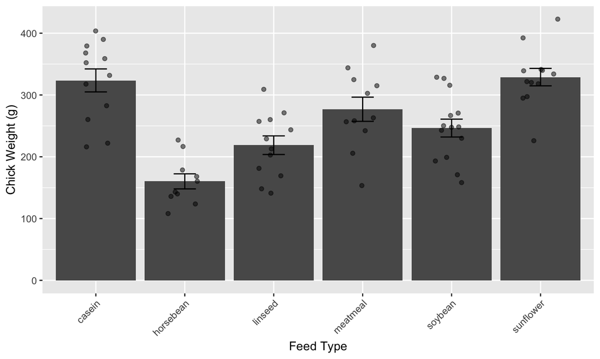

## Ditch the bar!

- The height of the bar in a bar plot **just represents the mean**.
- Bar area can be **misleading** because it **doesn't** represent spread in any way.
- You *could* get rid of bars entirely and just plot means as a point!
- This is great for when your data values are not all > 0 and you have few data points.